# Mozartology

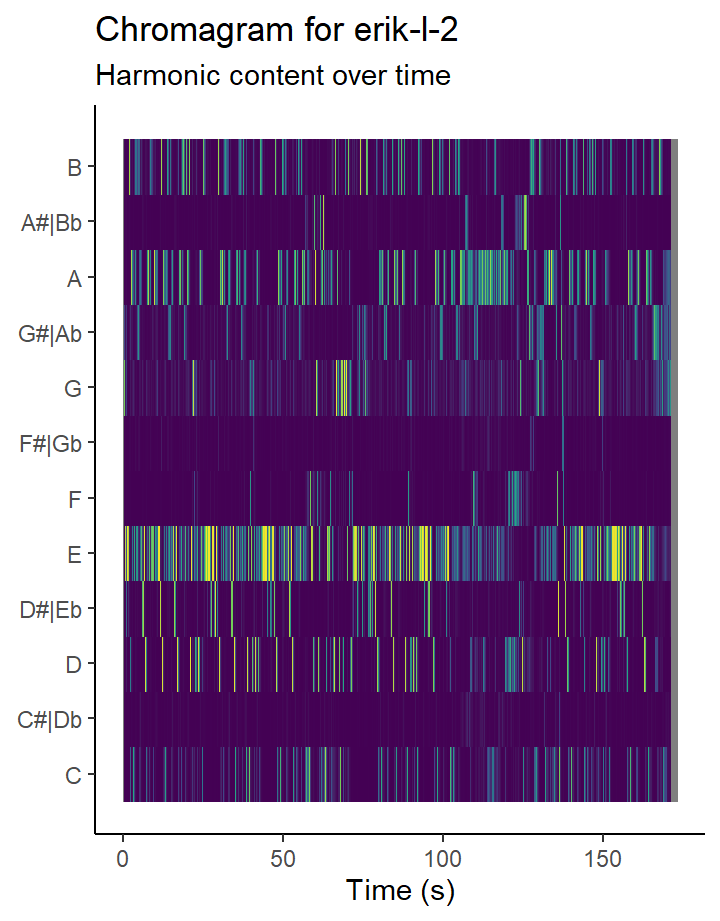

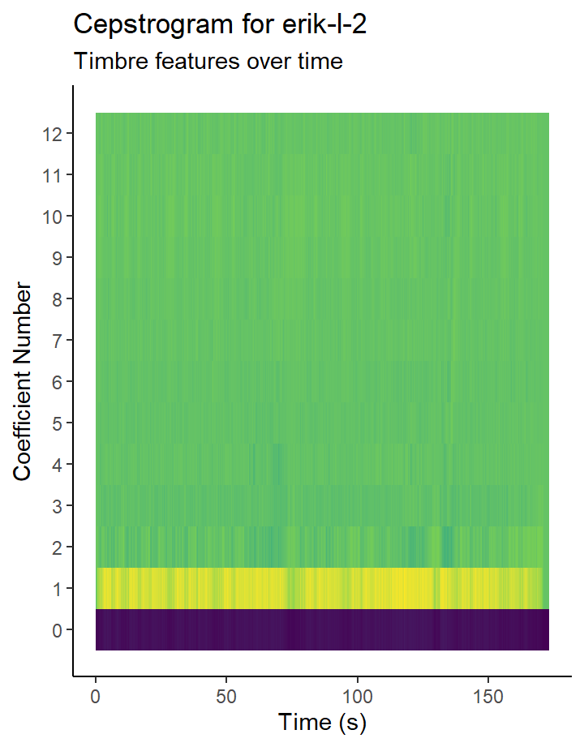

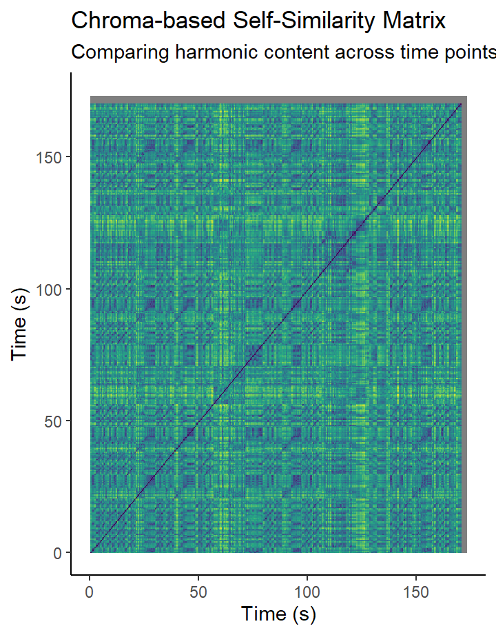

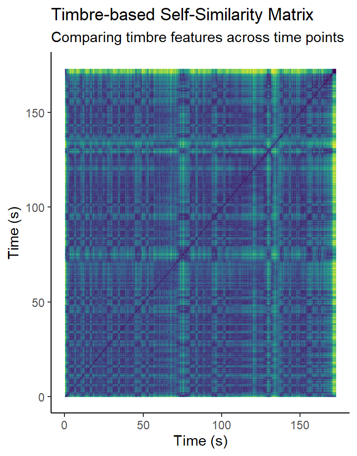

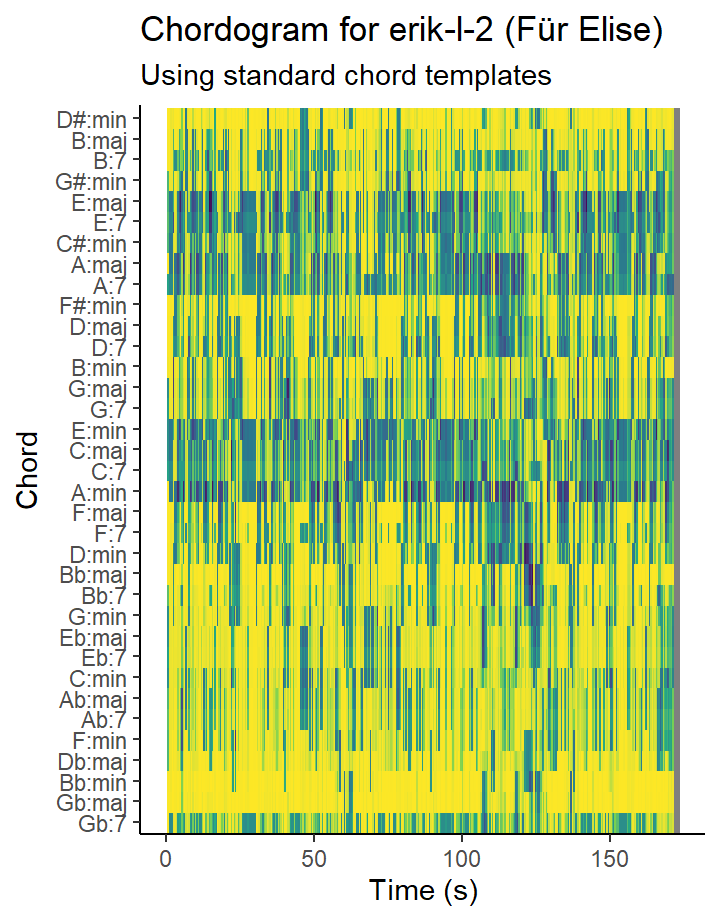

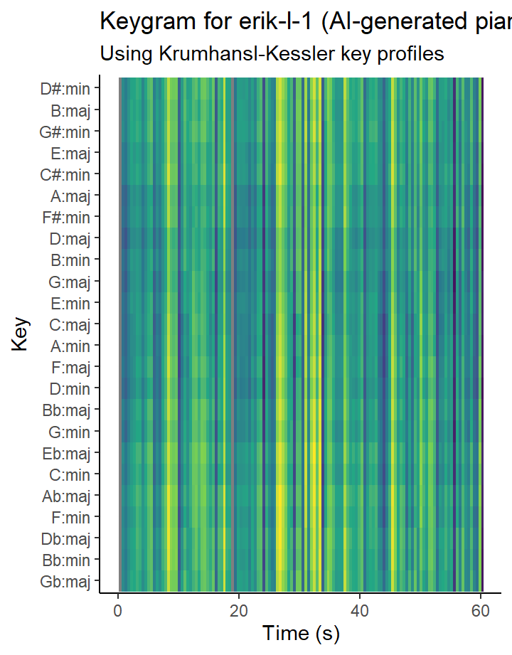

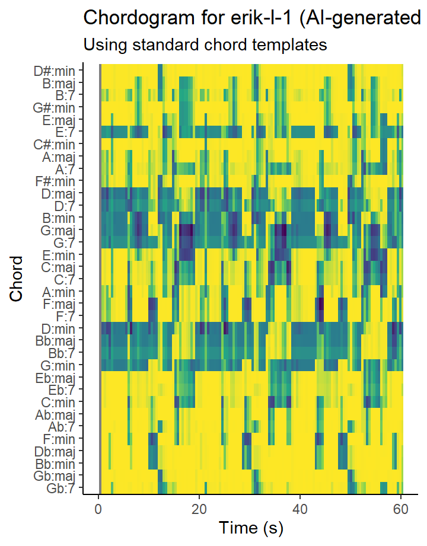

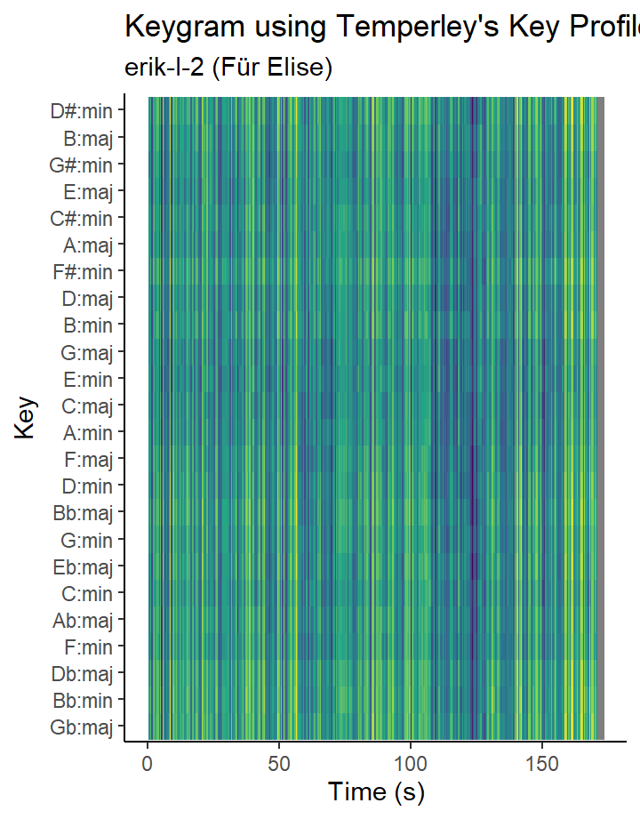

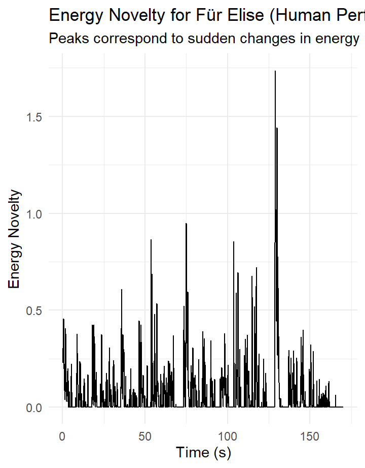

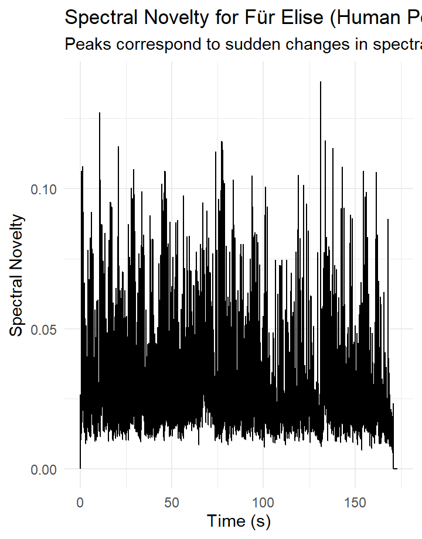

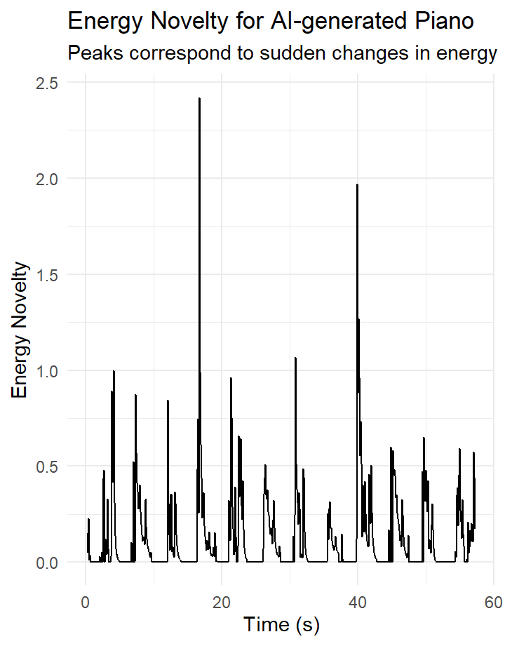

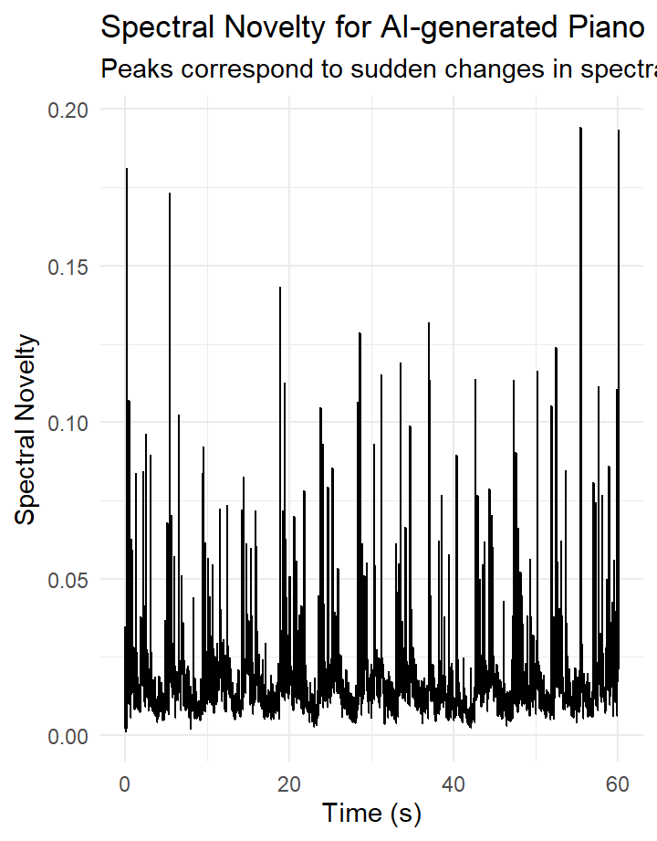

[8 more figures not shown]

# Introduction

### Für Elise: Human vs. AI-Generated Piano – A Musical Analysis

Few pieces of music are as instantly recognizable as Für Elise by Ludwig van Beethoven. For many, including myself, this composition carries a sense of nostalgia, bringing back memories of childhood and the sound of a piano filling the home. However, with the rapid advancements in artificial intelligence, we now face an intriguing question: can AI truly replicate the nuance and emotion of a human performance?

In this analysis, I compare a real human performance of Für Elise with an AI-generated attempt using Jen, a tool designed to create music based on text prompts. My initial attempt to generate the piece using the prompt “Piano, Bagatelle nr. 25 in A minor, Für Elise, Beethoven” resulted in a far-from-accurate rendition, raising important questions about the current state of AI music generation.

By examining aspects such as melody, timing, expression, and overall structure, this analysis will explore the differences between human musicianship and AI-generated music.

Visualisations on the next page!

# Homework 7

### Musical Feature Analysis

[interactive chart not shown]

The AI generated piano song scores relative low on all metrics while Für Elise has a relatively high bpm, low danceability and average onset rate. The fact that both piano songs have a low danceability isn’t surprising, and it’s great to see that Essentia is able to capture this feature well!

# Homework 9

### Homework 9

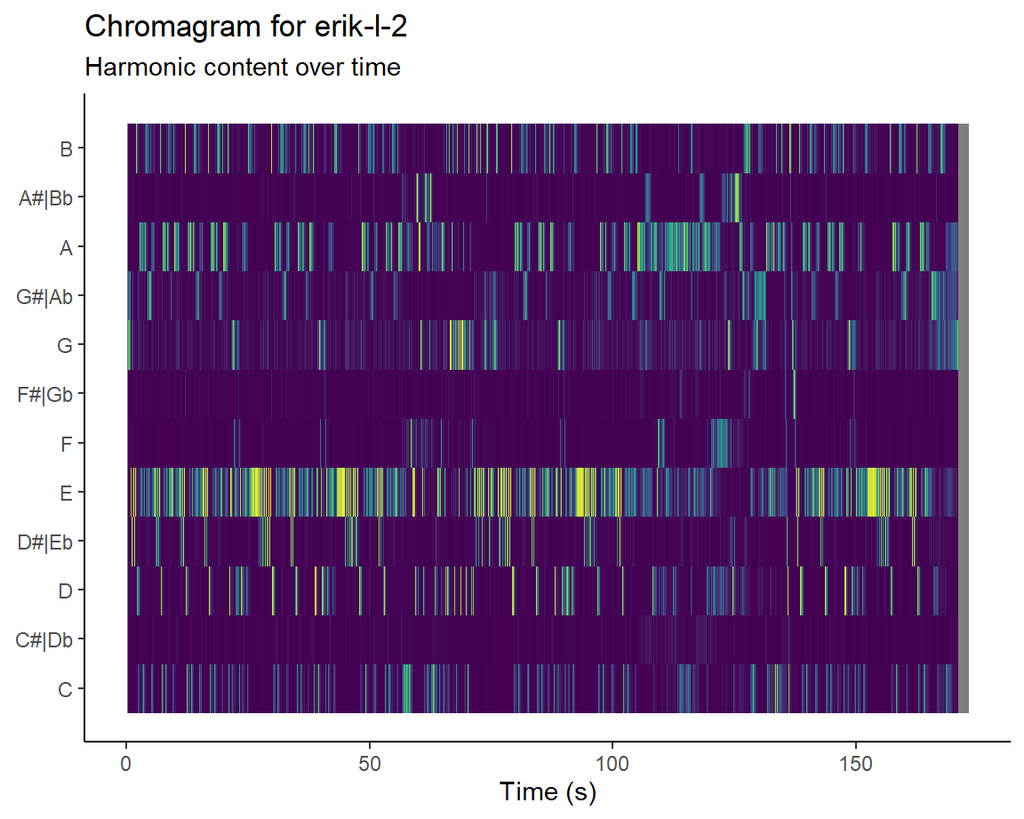

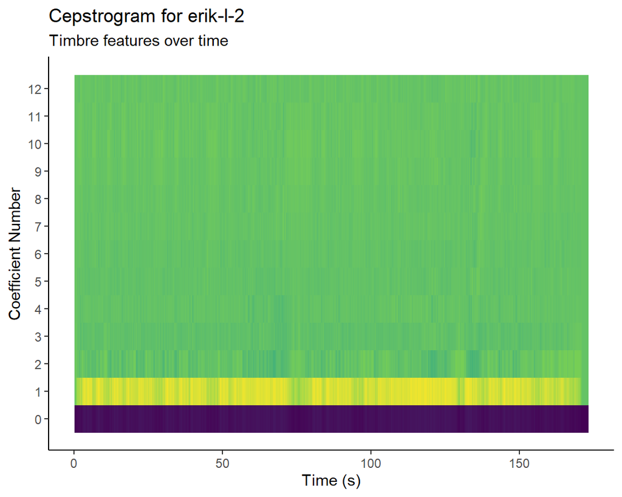

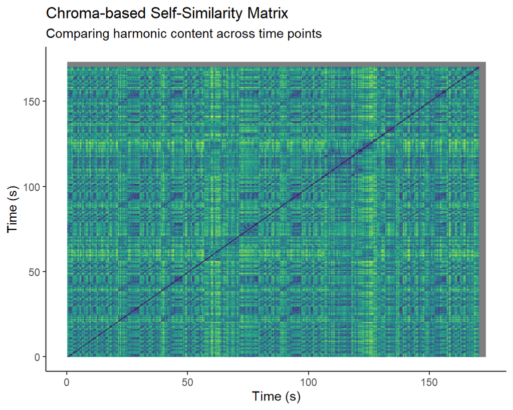

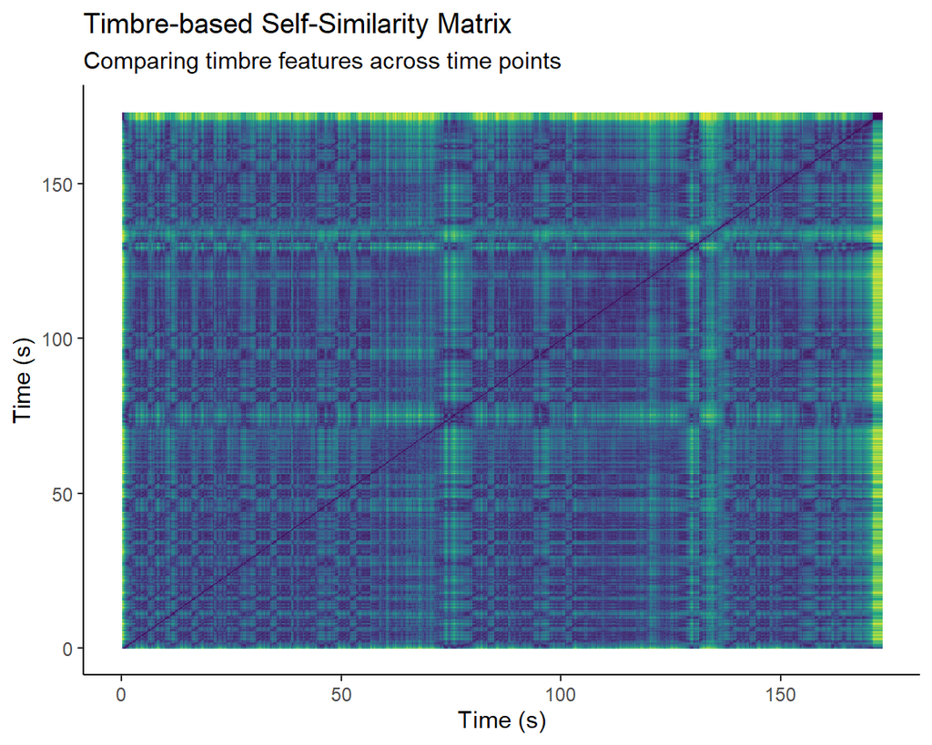

# Homework 10

### Chordogram - Für Elise

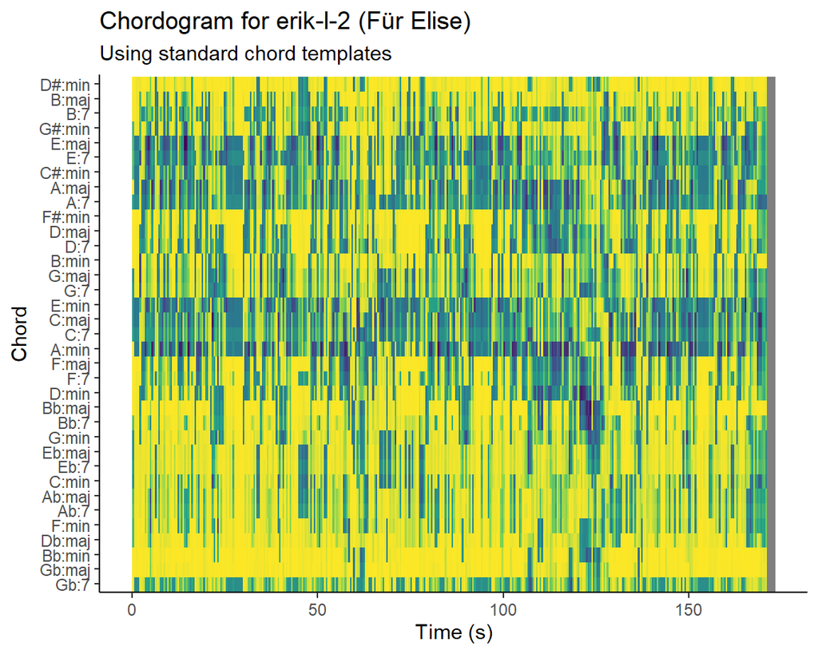

### Keygram - AI Piano

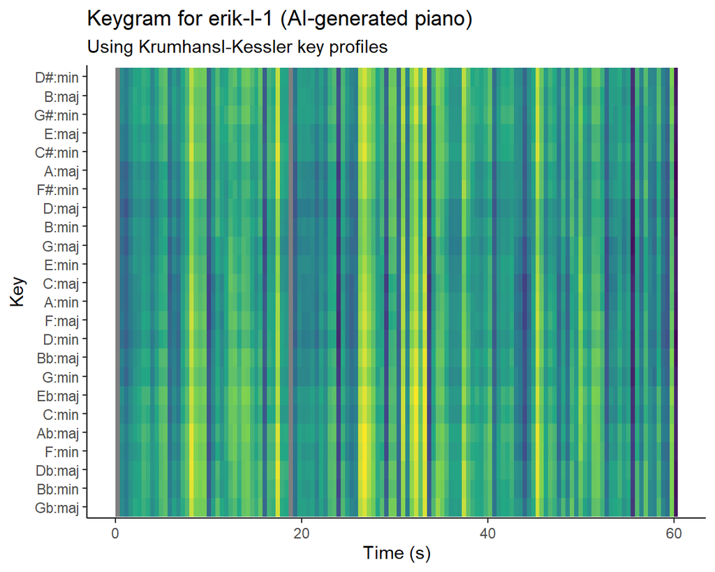

### Chordogram - AI Piano

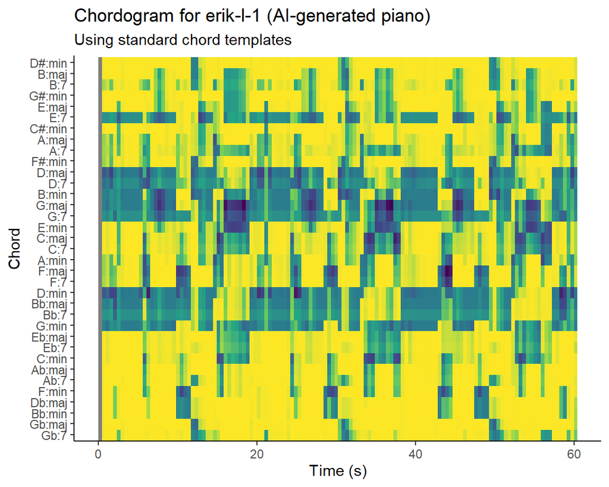

### Temperley Analysis

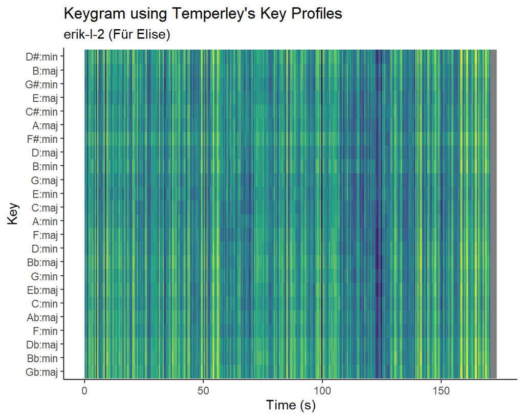

# Homework 11

### Energy Novelty Function

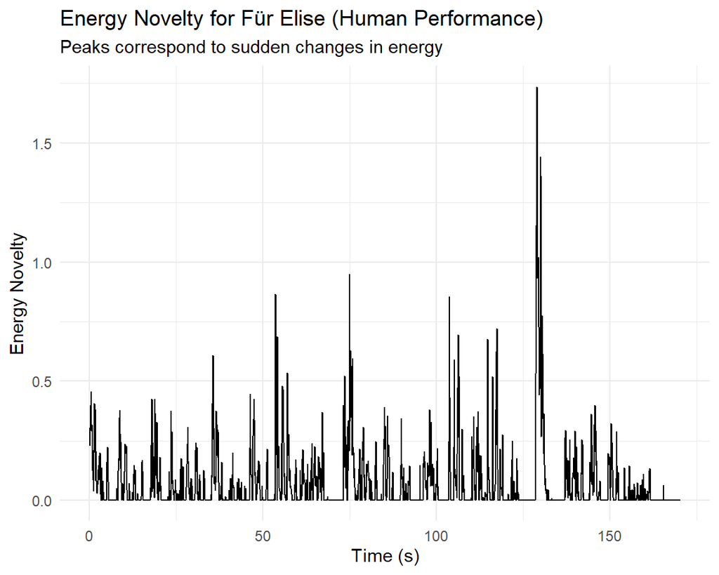

### Spectral Novelty Function

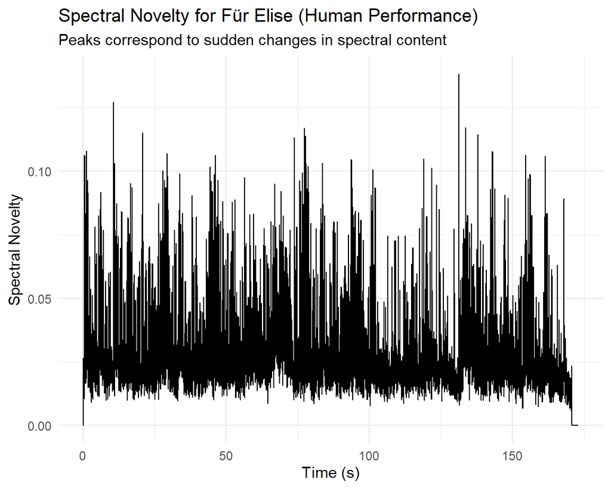

### AI-generated Piano Energy Novelty

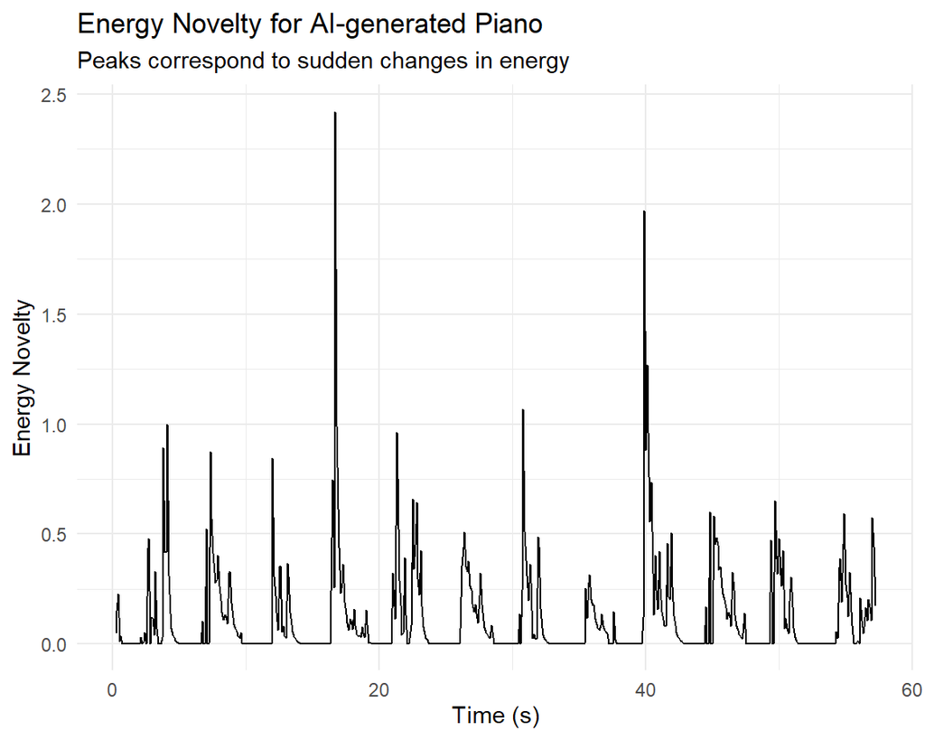

### AI-generated Piano Spectral Novelty

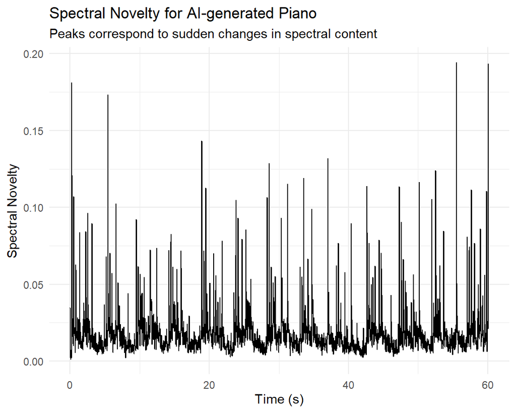

### Regular Tempogram (Human Performance)

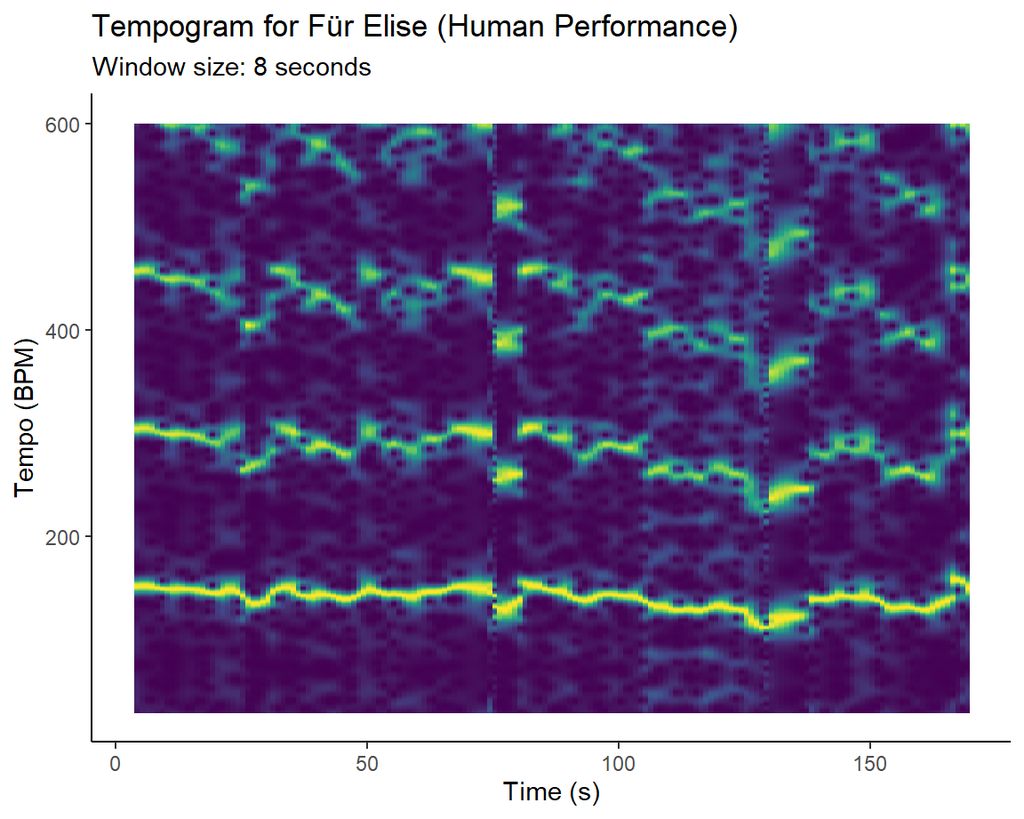

### Cyclic Tempogram (Human Performance)

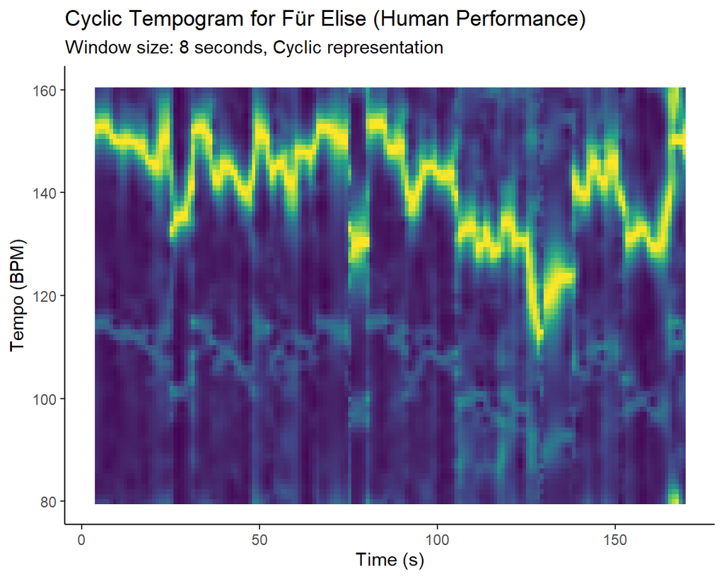

### Regular Tempogram (AI-generated Piano)

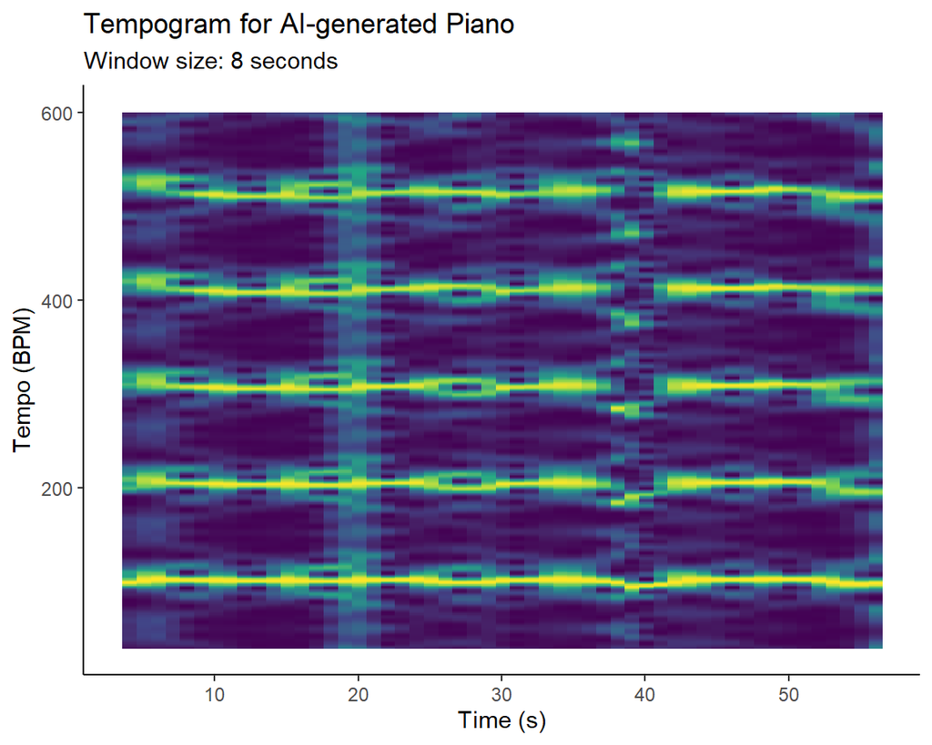

### Cyclic Tempogram (AI-generated Piano)

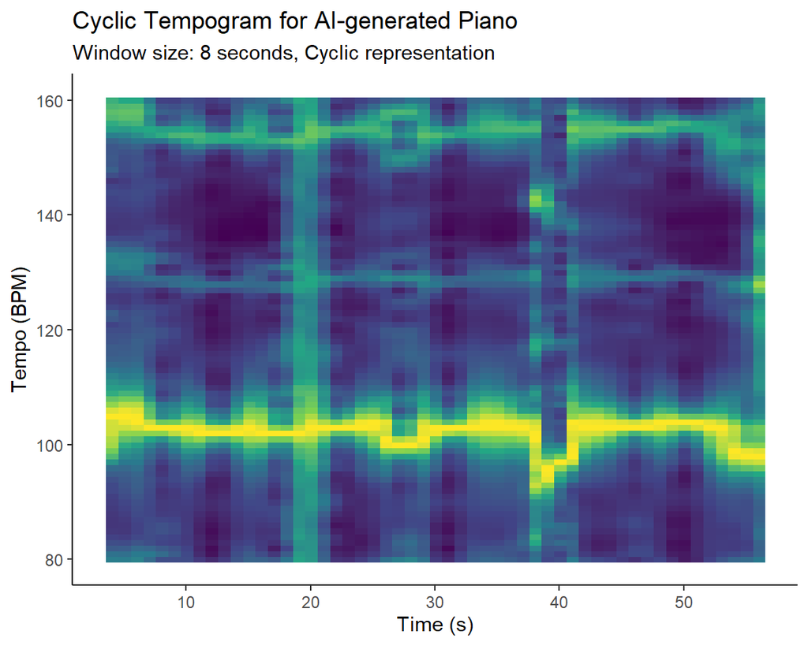

# Homework 12

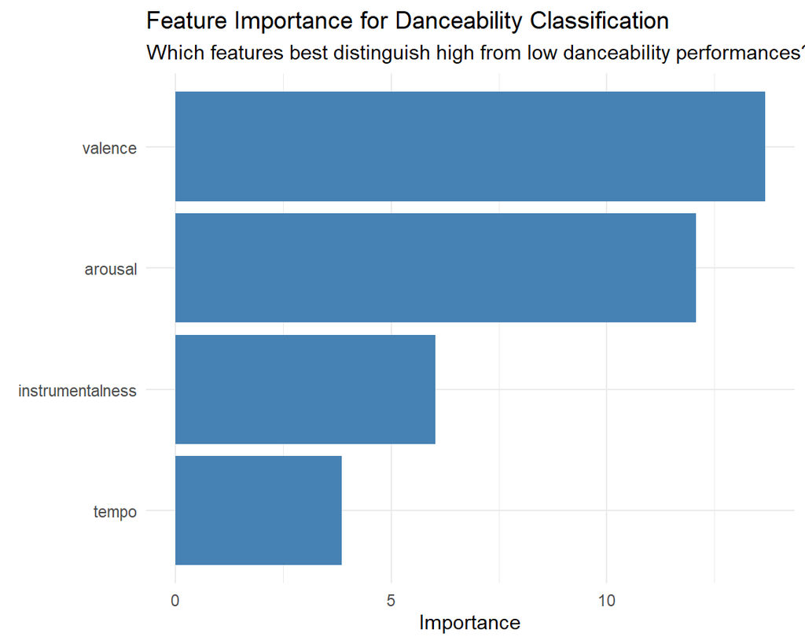

### Model Performance

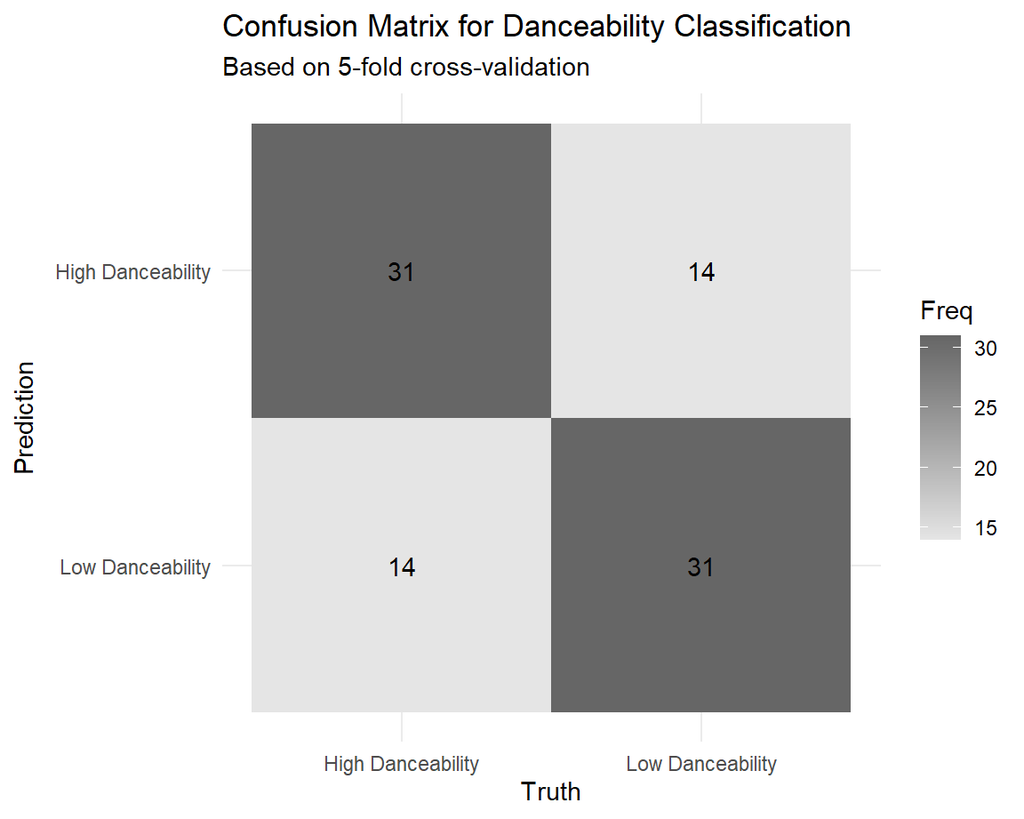

[output not shown]

### Improved Model with Feature Selection

[figure not shown]

[output not shown]

### Key Feature Visualization

[figure not shown]